# Powerwall Email Messaging Test — Pilot Results

3/10/26 v1

## Summary

This pilot tested three Powerwall email message variants among existing solar customers who had **already (mostly) been called by the call-center at least once**. Savings messaging produced the highest reply rate, but the sample generated too few replies to support a conclusive statistical result. The main recommendation is to repeat the test on a **fresh list of ~2,000 customers**.

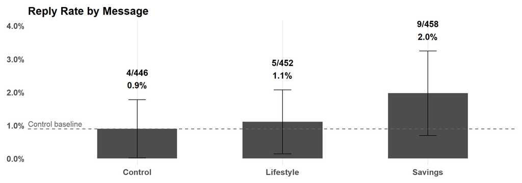

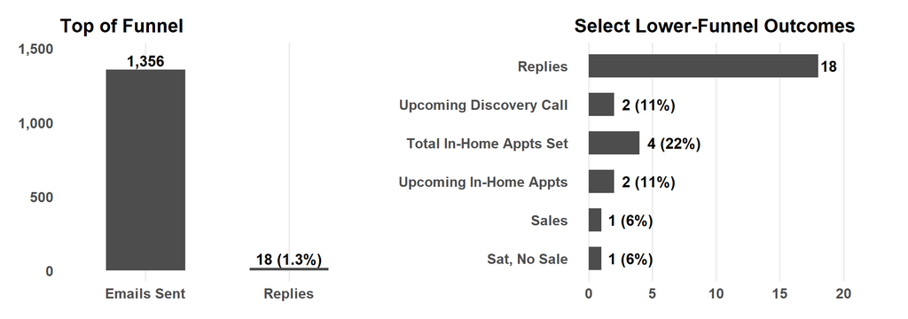

Note: Leads (replies) are still being worked on. Additional appointments may be set.

## Interpretation and Recommendations

Interpretation:

- Although there were nominal differences in reply rates, there were not enough replies to provide conclusive statistical evidence.
- Because the call center had already (mostly) called through this list and set ~190 appointments before emails were sent, many of the most interested customers were already identified (and were filtered out of the email list). Response rates may be much higher in a new audience.
- Despite this constraint, the campaign generated replies, appointments, and one sale (so far), demonstrating that email can reach customers who may be unresponsive to calls or texts.

Primary recommendation:

- Run a second test on ~2,000 fresh customers who have not yet been called.
- If consistent evidence is found supporting one message, emphasize it in future campaigns.

Additional opportunity:

- Emailing a fresh list will also support the call center. Because the team will not realistically be able to call through another large tranche of customers before the deadline, email responses can help identify the highest-interest customers for prioritization, potentially finding sales we’ll miss if only do manual calls and texts.

Additional recommendation:

- For the same reason, we should consider running a text campaign as well.